# exploratory analysis

Andy Cox

02/12/2016

# Data Science Specialization Capstone Project

## Introduction

In this capstone you will work on understanding and building predictive text models like those used by SwiftKey.

This course will start with the basics, analyzing a large corpus of text documents to discover the structure in the data and how words are put together. It will cover cleaning and analyzing text data, then building and sampling from a predictive text model. Finally, you will use the knowledge you gained in data products to build a predictive text product you can show off to your family, friends, and potential employers.

You will use all of the skills you have learned during the Data Science Specialization in this course, but you’ll notice that we are tackling a brand new application: analysis of text data and natural language processing. This choice is on purpose. As a practicing data scientist you will be frequently confronted with new data types and problems. A big part of the fun and challenge of being a data scientist is figuring out how to work with these new data types to build data products people love. The capstone will be evaluated based on the following assessments:

An introductory quiz to test whether you have downloaded and can manipulate the data. An intermediate R markdown report that describes in plain language, plots, and code your exploratory analysis of the course data set. Two natural language processing quizzes, where you apply your predictive model to real data to check how it is working. A Shiny app that takes as input a phrase (multiple words), one clicks submit, and it predicts the next word. A 5 slide deck created with R presentations pitching your algorithm and app to your boss or investor. During the capstone you can get support from your fellow students, from us, and from the engineers at SwiftKey. But we really want you to show your independence, creativity, and initiative. We have been incredibly impressed by your performance in the classes up until now and know you can do great things.

We have compiled some basic natural language processing resources below. You are welcome to use these resources or any others you can find while performing this analysis. One thing to keep in mind is that we do not expect you to become a world’s expert in natural language processing. The point of this capstone is for you to show you can explore a new data type, quickly get up to speed on a new application, and implement a useful model in a reasonable period of time. We think NLP is very cool and depending on your future goals may be worth studying more in-depth, but you can complete this project by using your general knowledge of data science and basic knowledge of NLP.

## Text Exploration blog, tweet and news text

The first step, as with any data driven project, is to explore and understand the data. We will look at look at the three corpora of US English texts, a set of internet blogs posts, a set of internet news articles, and a set of twitter messages. en_US.news.txt en_blogs.txt en_US.twitter.txt

We collect the following forms of information:

1. file size
2. number of lines
3. number of words
4. number of non-empty lines
5. number of characters
6. number of non-white characters
7. distribution of words

## Data

The data is available as a ZIP compressed archive, which is downloadable from [here](https://d396qusza40orc.cloudfront.net/dsscapstone/dataset/Coursera-SwiftKey.zip).

A number of libraries are needed for this analysis I will also try out the ‘quanteda’ package for text analysis as I have used the ’tm package in the past

```r
#Load Libraries
#character string analysis
library(stringi)
#plotting
library(ggplot2)
#Text analysis
library(tm)
#Wordcloud
library(wordcloud)
#Fast access to large asci files package
library(LaF)
#Trying out the quanitda package
library(quanteda)
```

## Loading the Data

```r
setwd("/Users/AndyC/Dropbox/rdata/cousera/capstone_git")
# # specify the source and destination of the download
# destination_file <- "Coursera-SwiftKey.zip"
# source_file <- "http://d396qusza40orc.cloudfront.net/dsscapstone/dataset/Coursera-SwiftKey.zip"
#
# # execute the download
# download.file(source_file, destination_file)
# # extract the files from the zip file
# unzip(destination_file)
```

Inspect the unzipped files

```r
#find out which files where unzipped
#unzip(destination_file, list = TRUE )
# inspect the data
list.files("final")
```

```
## [1] "en_US"
```

```r
list.files("final/en_US")
```

```
## [1] "cleaned"           "en_US.blogs.txt"   "en_US.news.txt"
## [4] "en_US.twitter.txt" "sample"
```

The corpora are contained in a number of separate plain-text files, ther are three basic files in different languages, we will only use the english files for this project. We caniImport the files to the R environment as follows.

```r
# import the blogs and twitter datasets in text mode
blogs <- readLines("final/en_US/en_US.blogs.txt", encoding="UTF-8")
twitter <- readLines("final/en_US/en_US.twitter.txt", encoding="UTF-8")
news <- readLines("final/en_US/en_US.news.txt", encoding="UTF-8")
```

Although we have imported the files to R above, they are fairly large files. Its also possible to load them in the following manner, commented out here, and only shown for the news items corpus.

```r
# import the news dataset in binary mode
# con <- file("final/en_US/en_US.news.txt", open="rb")
# news <- readLines(con, encoding="UTF-8")
# close(con)
# rm(con)
```

# Basic Dimsions of the data sources

Determine the size of the files (presented in MegaBytes / MBs).

```r
# file size (in MegaBytes/MB)
paste0("File en_US.blogs.txt is ",round(file.info("final/en_US/en_US.blogs.txt")$size   / 1024^2,1), " Megabytes")
```

```
## [1] "File en_US.blogs.txt is 200.4 Megabytes"
```

```r
paste0("File en_US.news.txt is ",round(file.info("final/en_US/en_US.news.txt")$size   / 1024^2,1), " Megabytes")
```

```
## [1] "File en_US.news.txt is 196.3 Megabytes"
```

```r
paste0("File en_US.blogs.txt is ",round(file.info("final/en_US/en_US.twitter.txt")$size   / 1024^2,1), " Megabytes")
```

[output not shown]

We can produce some general summary statistics for the corpera as follows

```r
stri_stats_general( blogs )
```

```
##       Lines LinesNEmpty       Chars CharsNWhite
##      899288      899288   206824382   170389539
```

```r
stri_stats_general( news )
```

```
##       Lines LinesNEmpty       Chars CharsNWhite
##     1010242     1010242   203223154   169860866
```

```r
stri_stats_general( twitter )
```

```
##       Lines LinesNEmpty       Chars CharsNWhite
##     2360148     2360148   162096031   134082634
```

Next we count the words per item (line). We summarise the distibution of these counts per corpus, using summary statistics and a distibution plot.

```r
words_blogs   <- stri_count_words(blogs)
summary( words_blogs )
```

```
##    Min. 1st Qu.  Median    Mean 3rd Qu.    Max.
##    0.00    9.00   28.00   41.75   60.00 6726.00
```

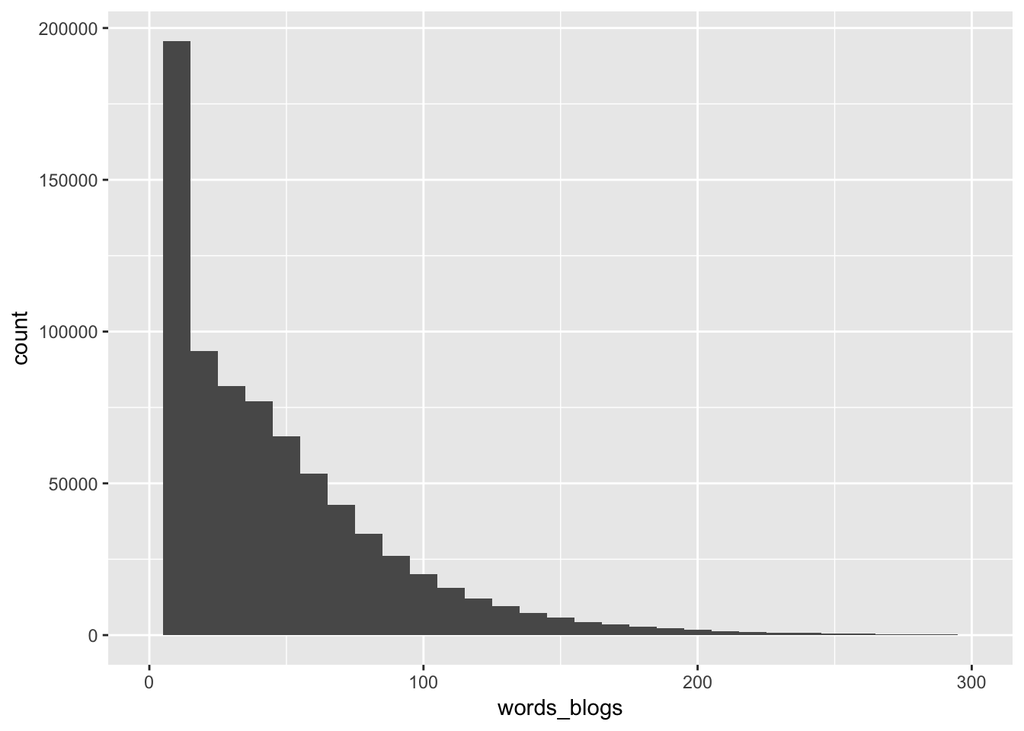

```r
qplot(   words_blogs,binwidth=10, xlim=c(0,300) )
```

```r
words_news    <- stri_count_words(news)
summary( words_news )
```

```
##    Min. 1st Qu.  Median    Mean 3rd Qu.    Max.
##    1.00   19.00   32.00   34.41   46.00 1796.00
```

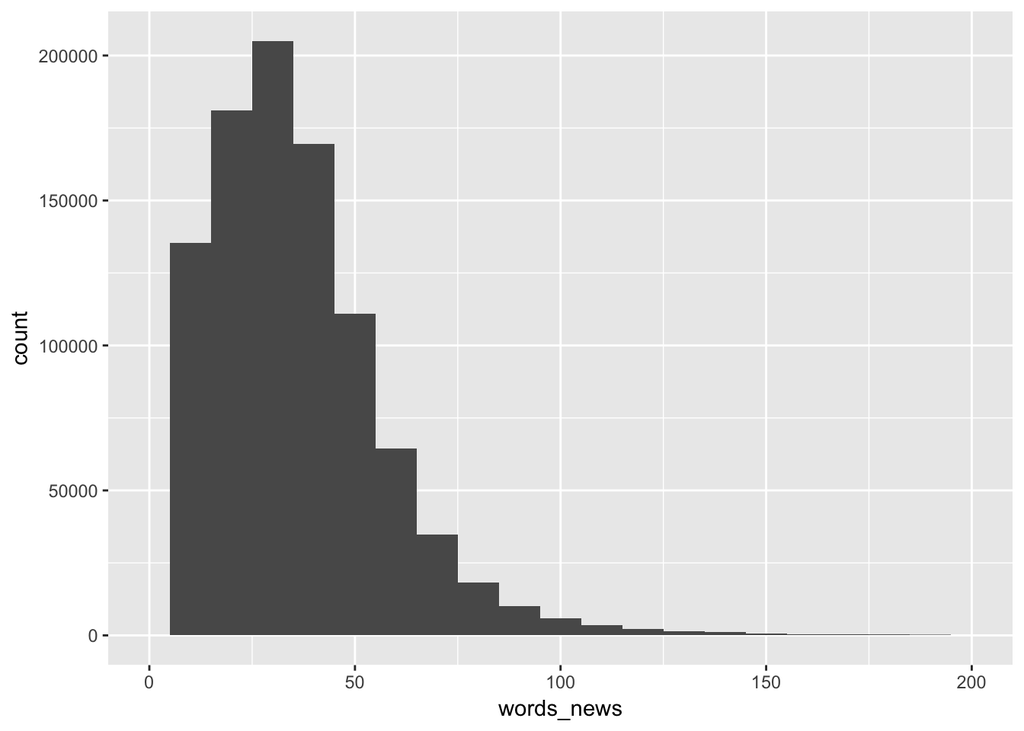

```r
qplot(   words_news,binwidth=10, xlim=c(0,200)  )
```

```r
words_twitter <- stri_count_words(twitter)
summary( words_twitter )
```

```
##    Min. 1st Qu.  Median    Mean 3rd Qu.    Max.
##    1.00    7.00   12.00   12.75   18.00   47.00
```

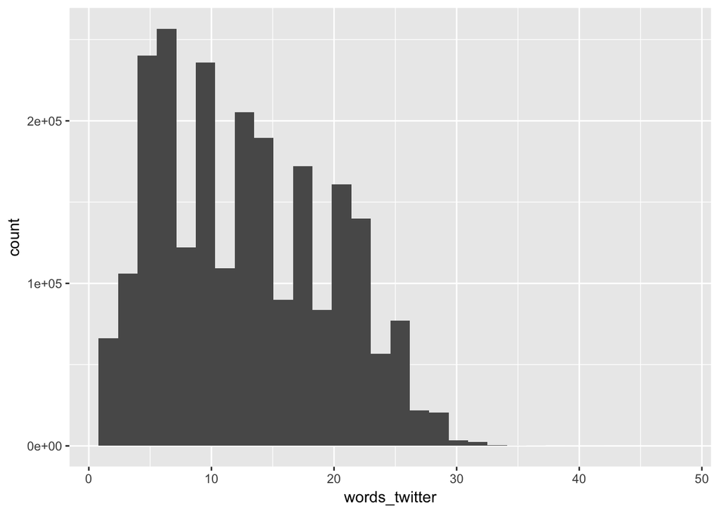

```r
qplot(   words_twitter )
```

```r
#clean up workspace
rm(list=ls())
```

# Data Capstone Exploration, more detailed questions

We have some more detailed questions we will need to address in this exploration they are listed below:

1. Clean the data from punctuation, stopwords and numbers
2. what are the distributions of word frequencies?
3. What are the frequencies of 2-grams and 3-grams in the dataset?
4. How many unique words do you need in a frequency sorted dictionary to cover 50% of all word instances in the language? 90%?
5. How do you evaluate how many of the words come from foreign languages?
6. Can you think of a way to increase the coverage – identifying words that may not be in the corpora or using a smaller number of words in the dictionary to cover the same number of phrases?

## Creating smaller files for code development and testing

In order to make code development more efficient, its a good idea to create some smaller sampled files to work with. This way we will not be delayed waiting for code execution. Once developed we can switch to adapting to the full size files

```r
# load dataset
# #Create some sample files to work wiht more quickly
# blogs1<-sample_lines("final/en_US/en_US.blogs.txt", 10000, nlines = NULL)
# news1<-sample_lines("final/en_US/en_US.news.txt", 10000, nlines = NULL)
# twitter1<-sample_lines("final/en_US/en_US.twitter.txt", 10000, nlines = NULL)
#
# if(!(dir.exists("final/en_US/sample"))){
#     dir.create("final/en_US/sample")
#
#     write(blogs1, file = "final/en_US/sample/en_US.blogs_sample.txt",append = FALSE, sep = "/t")
#     write(news1, file = "final/en_US/sample/en_US.news_sample.txt",append = FALSE, sep = "/t")
#     write(twitter1, file = "final/en_US/sample/en_US.twitter_sample.txt",append = FALSE, sep = "/t")
#     rm(list=c("blogs1","news1","twitter1"))
# }
```

### 1. Clean the data from punctuation, stopwords and numbers

Here we clean up the data to remove punctuation, stopwords and numbers. Although we should note that the period may be useful for text prediction. But we will ignore all punctuation in this initial phase of the project.

```r
#Cleaning the data

folder.dataset.english <- 'final/en_US/sample'
corpus <- VCorpus(DirSource(directory=folder.dataset.english, encoding = "UTF-8"),  readerControl = list(language = "en"))

# remove URLs
toSpace <- content_transformer(function(x, pattern) gsub(pattern, " ", x))
corpus <- tm_map(corpus, toSpace, "(f|ht)tp(s?)://(.*)[.][a-z]+")

# remove RTs and vias (mostly from tweets)
toSpace <- content_transformer(function(x, pattern) gsub(pattern, " ", x))
corpus <- tm_map(corpus, toSpace, "RT |via ")

# replace twitter account names by space
toSpace <- content_transformer(function(x, pattern) gsub(pattern, " ", x))
corpus <- tm_map(corpus, toSpace, "@[^\\s]+")


# to lower case
corpus <- tm_map(corpus, content_transformer(tolower))

# common text cleaning steps
getTransformations()
```

```
## [1] "removeNumbers"     "removePunctuation" "removeWords"
## [4] "stemDocument"      "stripWhitespace"
```

```r
# remove stopwords
corpus <- tm_map(corpus, removeWords, stopwords("english"))

# remove numbers
corpus <- tm_map(corpus, removeNumbers)

# remove punctuation
corpus <- tm_map(corpus, removePunctuation)

# filter profanity

# http://www.frontgatemedia.com/a-list-of-723-bad-words-to-blacklist-and-how-to-use-facebooks-moderation-tool/
terms.to.block <- read.csv(file ='dictionaries/Terms-to-Block.csv', stringsAsFactors=F, skip=3)

terms.to.block <- terms.to.block[,2]
terms.to.block <- unlist(gsub(",", "", terms.to.block))
profanity.filter <- terms.to.block

corpus <- tm_map(corpus, removeWords, profanity.filter)

# remove double whitespaces
corpus <- tm_map(corpus, stripWhitespace)
```

#### 3. (and Q2) What are the frequencies of unigrams, bigrams and trigrams in the dataset?

```r
#clean up
rm(list=ls())

#Thought I would try out the quantida package to see how it goes

folder.dataset.english <- 'final/en_US/sample'

# vector of full filenames for a recursive structure
x<-textfile(list.files(path = folder.dataset.english, pattern = "\\.txt$",
                    full.names = TRUE, recursive = TRUE))

myCorpus <- corpus(x=x)  # build the corpus
myCorpus<-toLower(myCorpus, keepAcronyms = TRUE)
summary(myCorpus)
```

```
##                       Text Types Tokens Sentences
## 1   en_US.blogs_sample.txt 12623  93587       715
## 2    en_US.news_sample.txt 12842  82692       248
## 3 en_US.twitter_sample.txt  6078  31111      1137
```

```r
myCorpus1<-tokenize(myCorpus, removeNumbers=TRUE, removePunct = TRUE,
  removeSymbols = TRUE, removeSeparators = TRUE, removeTwitter = TRUE,
  removeHyphens = FALSE, removeURL = TRUE, ngrams = 1L, skip = 0L,
  concatenator = "_", simplify = FALSE, verbose = T)
```

[output not shown]

[output not shown]

[output not shown]

[output not shown]

[output not shown]

[output not shown]

```
## Finished tokenizing and cleaning 3 texts.
```

```r
mydfm <- dfm(myCorpus1, ngrams=1,ignoredFeatures = c("the", stopwords("english")))
```

```
##
##    ... indexing documents: 3 documents
```

```
##
##    ... indexing features:
```

```
## 21,968 feature types
```

```
## ...
```

```
## removed 238 features, from 174 supplied (glob) feature types
```

```
##    ... created a 3 x 21730 sparse dfm
##    ... complete.
## Elapsed time: 0.172 seconds.
```

```r
#Most frequenct words
wds<-dfm(myCorpus, ngrams = 1, verbose = TRUE, toLower = TRUE,
  removeNumbers = TRUE, removePunct = TRUE, removeSeparators = TRUE,
  removeTwitter = TRUE, stem = FALSE,ignoredFeatures=stopwords("english"))
```

[output not shown]

[output not shown]

```
##
##    ... indexing documents: 3 documents
```

```
##
##    ... indexing features:
```

```
## 21,400 feature types
```

```
## ...
```

```
## removed 168 features, from 174 supplied (glob) feature types
```

```
##    ... created a 3 x 21232 sparse dfm
##    ... complete.
## Elapsed time: 0.205 seconds.
```

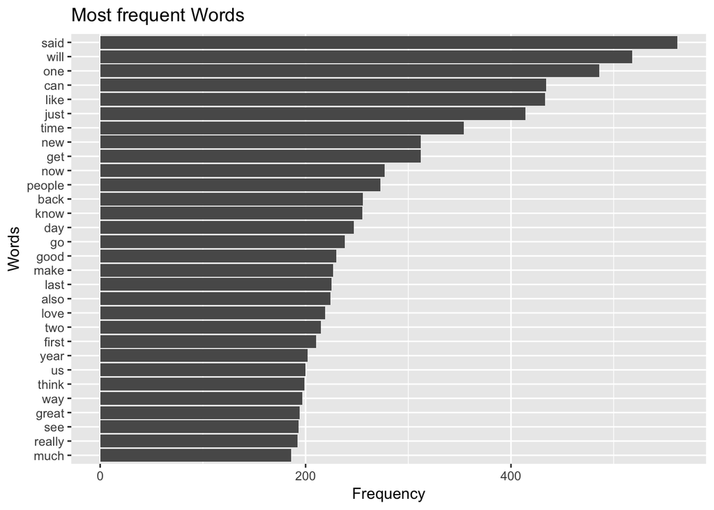

```r
allwds_freq<-sort(colSums(wds),decreasing=T)
wds<-topfeatures(wds, 30)
wds<-data.frame(cbind(names(wds),wds),stringsAsFactors =FALSE)
rownames(wds)<-NULL
colnames(wds)<-c("word","freq")
wds$freq<-as.numeric(wds$freq)

ggplot(wds, aes(reorder(word, freq),freq)) +
  geom_bar(stat = "identity") + coord_flip() +
  xlab("Words") + ylab("Frequency") +
  ggtitle("Most frequent Words")
```

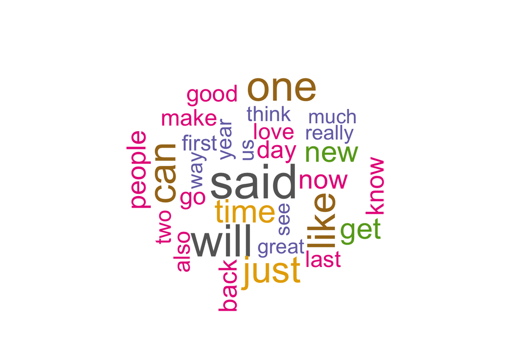

```r
wordcloud(wds$word,wds$freq,max.words=50,rot.per=.3,colors=brewer.pal(8,"Dark2"))
```

```r
#bigrams
bigrams<-dfm(myCorpus, ngrams = 2,verbose = TRUE, toLower = TRUE,
  removeNumbers = TRUE, removePunct = TRUE, removeSeparators = TRUE,
  removeTwitter = TRUE, stem = FALSE,ignoredFeatures=stopwords("english"))
```

[output not shown]

[output not shown]

```
##
##    ... indexing documents: 3 documents
```

```
##
##    ... indexing features:
```

```
## 109,512 feature types
```

```
## ...
```

```
## removed 67,804 features, from 174 supplied (glob) feature types
```

```
##    ... created a 3 x 41708 sparse dfm
##    ... complete.
## Elapsed time: 110 seconds.
```

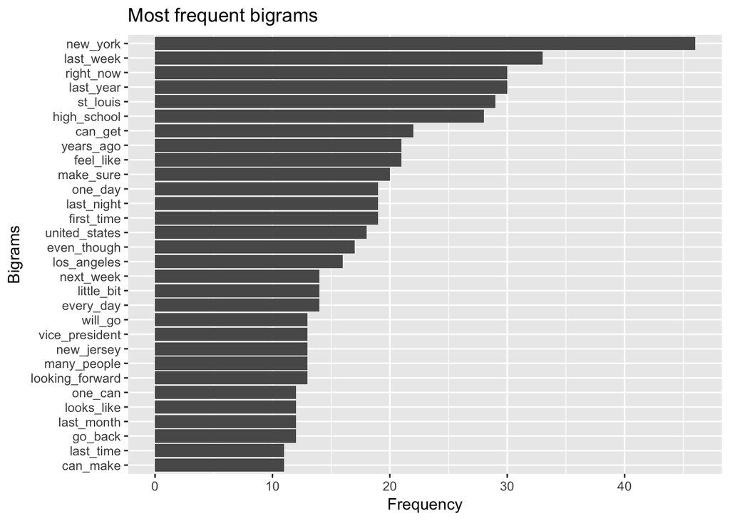

```r
bigrams<-topfeatures(bigrams, 30)
bigrams<-data.frame(cbind(names(bigrams),bigrams),stringsAsFactors =FALSE)
rownames(bigrams)<-NULL
colnames(bigrams)<-c("word","freq")
bigrams$freq<-as.numeric(bigrams$freq)

ggplot(bigrams, aes(reorder(word,freq), freq)) +
  geom_bar(stat = "identity") + coord_flip() +
  xlab("Bigrams") + ylab("Frequency") +
  ggtitle("Most frequent bigrams")
```

```r
#trigrams
trigrams<-dfm(myCorpus, ngrams = 3,verbose = TRUE, toLower = TRUE,
  removeNumbers = TRUE, removePunct = TRUE, removeSeparators = TRUE,
  removeTwitter = TRUE, stem = FALSE,ignoredFeatures=stopwords("english"))
```

[output not shown]

[output not shown]

```
##
##    ... indexing documents: 3 documents
```

```
##
##    ... indexing features:
```

```
## 160,378 feature types
```

```
## ...
```

```
## removed 138,451 features, from 174 supplied (glob) feature types
```

```
##    ... created a 3 x 21927 sparse dfm
##    ... complete.
## Elapsed time: 103 seconds.
```

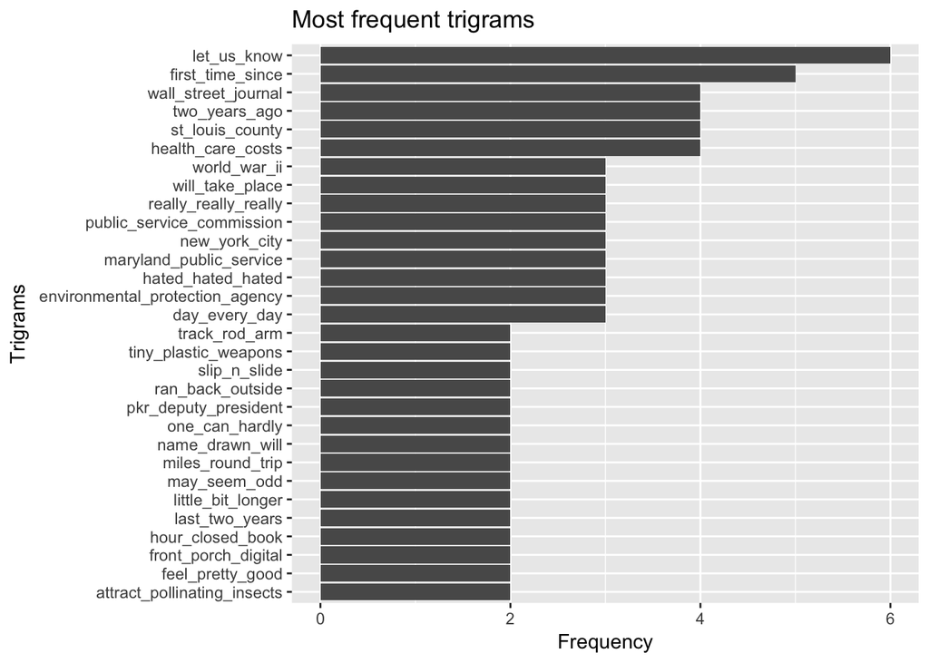

```r
trigrams<-topfeatures(trigrams, 30)
trigrams<-data.frame(cbind(names(trigrams),trigrams),stringsAsFactors =FALSE)
rownames(trigrams)<-NULL
colnames(trigrams)<-c("word","freq")
trigrams$freq<-as.numeric(trigrams$freq)

ggplot(trigrams, aes(reorder(word,freq), freq)) +
  geom_bar(stat = "identity") + coord_flip() +
  xlab("Trigrams") + ylab("Frequency") +
  ggtitle("Most frequent trigrams")
```

#### 4. How many unique words do you need in a frequency sorted dictionary to cover 50% of all word instances in the language?

```r
target1<-ceiling(sum(allwds_freq)*0.5)

for(i in 1:length(allwds_freq)){
sm<-sum(allwds_freq[1:i])
if(sm>=target1)break
}

paste0("Number of unique words needed to cover 50% of all words = ",i)
```

```
## [1] "Number of unique words needed to cover 50% of all words = 1117"
```

```r
#Now for 90% of all word instances
target1<-ceiling(sum(allwds_freq)*0.9)

for(i in 1:length(allwds_freq)){
sm<-sum(allwds_freq[1:i])
if(sm>=target1)break
}

paste0("Number of unique words needed to cover 90% of all words = ",i)
```

```
## [1] "Number of unique words needed to cover 90% of all words = 11801"
```

#### 5. How do you evaluate how many of the words come from foreign languages?

You could use and english dictionary to only include words from that language, similarly for other langauges

#### 6. Can you think of a way to increase the coverage – identifying words that may not be in the corpora or using #a smaller number of words in the dictionary to cover the same number of phrases?

Can correct common typos, misspellings and abreviations, could also use word stemming to reduce the number of unique words